# Dataset comparison

# Goals

- Determine which of the dataset cleaning methods is “best” for further investigation
- Check cross-validation approach to LDA

# Libraries used

```r
library(dplyr)
library(wranglR)
library(ggplot2)
library(stringr)
library(tm)
library(slam)
library(topicmodels)
```

# Load the data

Load each of the pre-computed sparse matrices; see R code for details, e.g.

- read-PostsData-zip.R
- read-PostsData-zip-with-tex.R
- read-PostsData-zip-aggressive-tex-removal.R

```r
# Load sparse matrix with tex
load(file = "data/sparse_matrix_w_tex.zip")
sparse_w_tex <- sparse
# Load sparse matrix with no tex
load(file = "data/sparse_matrix_no_tex.zip")
sparse_no_tex <- sparse
# Load original sparse matrix
load(file = "data/sparse_matrix.zip")
```

# Document selection

To fairly compare perplexities, fit the model on only a subset of documents.

```r
# Number of documents
D <- sparse$dimnames$Docs %>% length()
# Create 2 groups, 80% and 20% of the document indices
set.seed(3361)
rand.ind <- KFoldXVal(1:D, k = 2, prop = .8)
```

In the sparse document-term matrices, i corresponds to documents (rows) and j to terms (columns)

```r
# Function to create test matrix
split_set <- function(dtm, ind) {
  # Identify which rows i (documents) to keep
  sparse_ind <- dtm$i %in% ind
  # Original document number
  map_old <- 1:D
  # Remapped document number
  map_new <- cumsum(map_old %in% ind) * (map_old %in% ind)
  # Create sparse matrix keeping the elements that meet the above criteria
  dtm$i <- dtm$i[sparse_ind]
  dtm$i <- map_new[dtm$i]
  dtm$j <- dtm$j[sparse_ind]
  dtm$v <- dtm$v[sparse_ind]
  dtm$nrow <- max(map_new)
  dtm$dimnames$Docs <- dtm$dimnames$Docs[map_old %in% ind]

  #Return results
  return(dtm)
}
```

Now create the modeling datasets.

```r
sparse_mod <- split_set(sparse, rand.ind[[1]])
sparse_no_tex_mod <- split_set(sparse_no_tex, rand.ind[[1]])
sparse_tex_mod <- split_set(sparse_w_tex, rand.ind[[1]])
```

# Topic modeling

Try 25-topic models.

```r
topic_s <- LDA(sparse_mod, k = 25, method = "VEM", control = list(seed = 8602, verbose = 1))
save(topic_s, file = "results/lda25_sparse.zip", compress = "xz")

topic_s_nt <- LDA(sparse_no_tex_mod, k = 25, method = "VEM", control = list(seed = 8602, verbose = 1))
save(topic_s_nt, file = "results/lda25_sparse_notex.zip", compress = "xz")

topic_s_wt <- LDA(sparse_w_tex, k = 25, method = "VEM", control = list(seed = 8602, verbose = 1))
save(topic_s_wt, file = "results/lda25_sparse_tex.zip", compress = "xz")
```

The top 20 terms for each topic follow.

```r
terms(topic_s, 20) %>% data.frame(stringsAsFactors = FALSE)
```

| Topic.1 | Topic.2 | Topic.3 | Topic.4 | Topic.5 | Topic.6 | Topic.7 | Topic.8 | Topic.9 | Topic.10 | Topic.11 | Topic.12 | Topic.13 | Topic.14 | Topic.15 | Topic.16 | Topic.17 | Topic.18 | Topic.19 | Topic.20 | Topic.21 | Topic.22 | Topic.23 | Topic.24 | Topic.25 |
| --- | --- | --- | --- | --- | --- | --- | --- | --- | --- | --- | --- | --- | --- | --- | --- | --- | --- | --- | --- | --- | --- | --- | --- | --- |
| probability | distribution | frac | variables | data | standard | log | model | data | function | group | function | plot | statistics | distance | time | effects | matrix | test | sample | learning | likelihood | model | score | correlation |
| number | normal | left | variable | set | variance | data | regression | time | problem | groups | code | data | statistical | clustering | series | effect | covariance | hypothesis | confidence | features | prior | regression | scores | coefficient |
| probabilities | random | beta | regression | model | sample | outliers | linear | number | vector | treatment | values | points | analysis | cluster | model | model | pca | tests | interval | network | parameters | models | items | age |
| event | distributions | begin | dependent | cross | size | transformation | error | set | question | control | package | line | good | data | data | random | factor | null | population | feature | bayesian | logistic | word | relationship |
| events | distributed | end | independent | training | deviation | price | residuals | question | case | analysis | method | values | book | clusters | forecast | interaction | analysis | significant | intervals | neural | parameter | linear | words | odds |
| state | probability | sigma | categorical | validation | error | change | errors | day | random | study | algorithm | point | methods | means | arima | mixed | components | testing | sampling | kernel | distribution | fit | user | correlated |
| chance | variable | sum | continuous | test | values | rate | ols | people | equation | effect | problem | plots | paper | points | trend | fixed | data | difference | samples | input | estimate | data | item | coefficients |
| times | function | theta | predictor | accuracy | average | outlier | variance | questions | sum | patients | output | graph | data | similarity | process | level | component | data | size | training | posterior | function | text | ratio |
| time | density | align | predictors | performance | calculate | transformed | coefficients | analysis | linear | risk | find | curve | research | algorithm | stationary | anova | principal | statistic | estimate | class | estimator | aic | users | correlations |
| coin | poisson | text | multiple | class | number | sales | estimate | missing | definition | outcome | results | axis | theory | number | period | factor | variables | significance | bootstrap | machine | model | selection | document | effect |

[output cut: 10 more lines]

```r
terms(topic_s_nt, 20) %>% data.frame(stringsAsFactors = FALSE)
```

| Topic.1 | Topic.2 | Topic.3 | Topic.4 | Topic.5 | Topic.6 | Topic.7 | Topic.8 | Topic.9 | Topic.10 | Topic.11 | Topic.12 | Topic.13 | Topic.14 | Topic.15 | Topic.16 | Topic.17 | Topic.18 | Topic.19 | Topic.20 | Topic.21 | Topic.22 | Topic.23 | Topic.24 | Topic.25 |
| --- | --- | --- | --- | --- | --- | --- | --- | --- | --- | --- | --- | --- | --- | --- | --- | --- | --- | --- | --- | --- | --- | --- | --- | --- |
| matrix | standard | probability | statistics | correlation | space | model | code | distribution | distance | series | group | test | age | time | model | random | function | training | sample | data | question | regression | data | class |
| covariance | variance | number | data | variables | points | effects | package | normal | clustering | time | groups | hypothesis | score | data | data | variables | likelihood | validation | size | plot | answer | model | day | features |
| pca | error | probabilities | statistical | variable | kernel | effect | data | distributions | cluster | trend | treatment | tests | people | event | models | variable | parameters | cross | confidence | values | make | variables | days | data |
| factor | deviation | state | analysis | continuous | vector | random | function | density | data | stationary | anova | null | data | times | fit | independent | prior | set | samples | line | people | variable | number | classification |
| variables | estimate | chance | book | data | dimensional | interaction | values | probability | clusters | var | analysis | testing | survey | events | prediction | conditional | parameter | network | population | points | good | linear | month | feature |
| analysis | errors | markov | paper | categorical | linear | level | output | function | means | correlation | effect | statistic | risk | process | forecast | question | problem | data | interval | missing | results | logistic | price | set |
| components | estimator | coin | methods | negative | function | mixed | run | distributed | algorithm | process | control | difference | odds | rate | arima | sum | posterior | neural | sampling | plots | sense | coefficients | year | classifier |
| correlation | calculate | times | learning | binomial | vectors | fixed | algorithm | gaussian | number | autocorrelation | data | data | ratio | number | time | case | log | learning | intervals | outliers | problem | dependent | sales | accuracy |
| data | estimates | binomial | good | poisson | noise | models | python | uniform | similarity | lag | design | values | year | species | parameters | definition | maximum | input | estimate | median | high | predictors | week | classes |
| component | formula | event | bayesian | scale | point | factor | results | gamma | words | panel | subjects | significance | survival | poisson | aic | expectation | bayesian | model | data | graph | true | independent | average | training |

[output cut: 10 more lines]

```r
terms(topic_s_wt, 20) %>% data.frame(stringsAsFactors = FALSE)
```

| Topic.1 | Topic.2 | Topic.3 | Topic.4 | Topic.5 | Topic.6 | Topic.7 | Topic.8 | Topic.9 | Topic.10 | Topic.11 | Topic.12 | Topic.13 | Topic.14 | Topic.15 | Topic.16 | Topic.17 | Topic.18 | Topic.19 | Topic.20 | Topic.21 | Topic.22 | Topic.23 | Topic.24 | Topic.25 |
| --- | --- | --- | --- | --- | --- | --- | --- | --- | --- | --- | --- | --- | --- | --- | --- | --- | --- | --- | --- | --- | --- | --- | --- | --- |
| day | distribution | test | network | data | matrix | score | frac | distance | variable | group | data | series | time | data | correlation | statistics | distribution | sample | theta | number | model | data | model | beta |
| data | normal | hypothesis | learning | code | mathbf | data | sum | data | variables | groups | plot | time | data | set | variables | statistical | values | standard | probability | probability | effects | age | regression | alpha |
| time | lambda | tests | neural | package | covariance | scores | left | clustering | regression | treatment | points | model | missing | model | coefficient | data | function | confidence | random | times | models | year | linear | gamma |
| days | sigma | null | function | function | pca | scale | sigma | cluster | logistic | anova | line | data | event | training | variable | analysis | density | size | distribution | total | effect | population | data | likelihood |
| state | random | data | algorithm | find | vector | factor | hat | clusters | dependent | control | plots | forecast | events | class | correlated | book | distributions | interval | probabilities | chance | random | years | fit | prior |
| price | gaussian | chi | input | word | boldsymbol | items | text | means | categorical | effect | values | arima | survival | validation | effect | methods | estimator | variance | mid | values | interaction | people | values | log |
| month | distributions | testing | output | words | components | analysis | bar | points | continuous | data | point | trend | values | features | significant | good | random | population | function | numbers | fixed | individuals | error | parameters |
| number | distributed | statistic | problem | dataset | component | outliers | end | weights | independent | analysis | graph | stationary | rate | cross | relationship | paper | median | error | mathbb | count | intercept | species | function | posterior |
| week | sim | difference | gradient | python | vectors | item | begin | algorithm | model | subjects | curve | process | times | classification | correlations | question | uniform | samples | omega | choose | mixed | survey | models | parameter |
| sales | variance | significance | networks | software | linear | questions | sqrt | similarity | binary | design | red | forecasting | risk | feature | coefficients | models | max | estimate | conditional | expected | level | income | residuals | bayesian |

[output cut: 10 more lines]

# Model comparison

Finally, model perplexity scores.

## Training data

```r
# Perplexity comparison data frame
compare <- data.frame(
  labels = c("no tex", "standard", "all tex"),
  perplexity = c(perplexity(topic_s_nt), perplexity(topic_s), perplexity(topic_s_wt)),
  words = c(length(sparse_no_tex_mod$dimnames$Terms),
            length(sparse_mod$dimnames$Terms),
            length(sparse_tex_mod$dimnames$Terms))
)
print(compare)
```

| labels | perplexity | words |
| --- | --- | --- |
| no tex | 1347.797 | 11905 |
| standard | 1316.077 | 12035 |
| all tex | 1244.647 | 12143 |

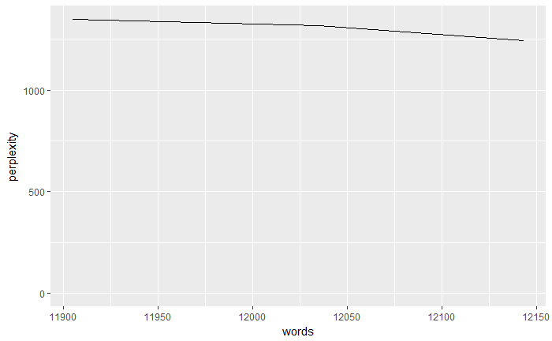

```r
compare %>% ggplot(aes(x = words, y = perplexity)) + geom_line() + ylim(0, max(compare$perp))
```

As expected, perplexity decreases as word count increases. There’s a slight elbow (concave) but these are very close. Now, for the holdout data.

## Prediction time

How well does the perplexity function scale?

```r
# Control objects
tests <- seq(50, 1000, by = 50)
times <- rep(0, times = length(tests))

# Iterate through tests
for (i in 1:length(tests)) {
  now <- Sys.time()
  tmp <- split_set(sparse, 1:tests[i])
  perplexity(topic_s, newdata = tmp)
  times[i] <- Sys.time() - now
}

# Save data
perplexity_scaling = data.frame(tests, times)
write.csv(perplexity_scaling, file = "results/lda25_perplex_scale.csv", row.names = FALSE)
```

Linear model of results:

```r
lm_perplex <- perplexity_scaling %>% lm(times ~ tests, data = .)
summary(lm_perplex)
```

```
Call:
lm(formula = times ~ tests, data = .)

Residuals:
     Min       1Q   Median       3Q      Max
-0.33966 -0.05758 -0.03637  0.05974  0.30468

Coefficients:
             Estimate Std. Error t value Pr(>|t|)
(Intercept) 0.7620101  0.0741083   10.28 5.81e-09 ***
tests       0.0119928  0.0001237   96.93  < 2e-16 ***
---
Signif. codes:  0 ‘***’ 0.001 ‘**’ 0.01 ‘*’ 0.05 ‘.’ 0.1 ‘ ’ 1

Residual standard error: 0.1595 on 18 degrees of freedom
Multiple R-squared:  0.9981,    Adjusted R-squared:  0.998
F-statistic:  9395 on 1 and 18 DF,  p-value: < 2.2e-16
```

That definitely looks linear. Confirm by plotting the results:

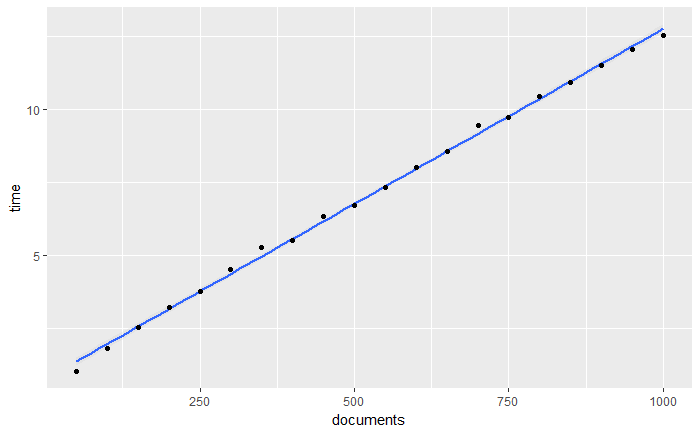

Definitely linear. So we expect the full holdout dataset to take:

```r
lm_perplex %>% predict(newdata = data.frame(tests = length(rand.ind[[2]]), times = 0)) %>% round() %>%
  paste(., "seconds")
```

```
[1] "222 seconds"
```

This is negligible compared to the time taken to fit the models in the first place.

## Holdout data results

Compute perplexities.

```r
# Holdout data
snt <- split_set(sparse_no_tex, rand.ind[[2]])
spa <- split_set(sparse, rand.ind[[2]])
swt <- split_set(sparse_w_tex, rand.ind[[2]])

# Perplexity comparison data frame
compare_datasets <- data.frame(
  labels = c("no tex", "standard", "all tex"),
  perplexity = c(perplexity(topic_s_nt, newdata = snt),
                 perplexity(topic_s, newdata = spa),
                 perplexity(topic_s_wt, newdata = swt)),
  words = c(length(sparse_no_tex_mod$dimnames$Terms), length(sparse_mod$dimnames$Terms), length(sparse_tex_mod$dimnames$Terms))
)

write.csv(compare_datasets, file = "results/lda25_compare.csv", row.names = FALSE)
```

```r
# Text summary
print(compare_datasets)
```

| labels | perplexity | words |
| --- | --- | --- |
| no tex | 1375.703 | 11905 |
| standard | 1342.886 | 12035 |
| all tex | 1234.714 | 12143 |

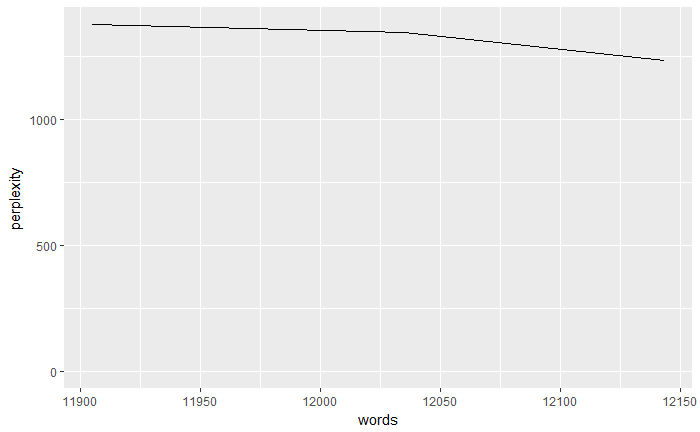

```r
# Graphical summary
compare_datasets %>% ggplot(aes(x = words, y = perplexity)) + geom_line() + ylim(0, max(compare_datasets$perp))
```

## Runtime comparison

```r
# Control
d <- 1000
k <- 25
times <- c(0, 0, 0)

# No TeX benchmark
now <- Sys.time()
LDA(split_set(sparse_no_tex_mod, 1:d), k = k, method = "VEM", control = list(seed = 24756, verbose = 1))
times[1] <- Sys.time() - now

# Sparse benchmark
now <- Sys.time()
LDA(split_set(sparse_mod, 1:d), k = k, method = "VEM", control = list(seed = 24756, verbose = 1))
times[2] <- Sys.time() - now

# TeX benchmark
now <- Sys.time()
LDA(split_set(sparse_tex_mod, 1:d), k = k, method = "VEM", control = list(seed = 24756, verbose = 1))
times[3] <- Sys.time() - now

# Save data
results <- data.frame(labels = c("no tex", "standard", "all tex"), secs = times * 60)
write.csv(results, file = "results/lda25_model_bench.csv", row.names = FALSE)
```

How long does it take to run each dataset?

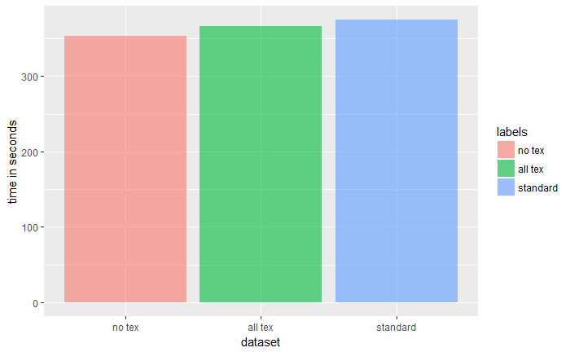

```r
results %>% mutate(labels = labels %>% relevel("no tex")) %>%
  ggplot(aes(x = labels, y = secs, fill = labels)) +
  labs(x = "dataset", y = "time in seconds") +
  geom_bar(stat = "identity", alpha = .6)
```